# HW11 - GAMs Coyotes and Wolves

Jamie Ash

11/09/2021

```r
# reading data from given csv
dogs <- read.csv(paste("..\\data\\", "wolf_coyote_hybrids.csv", sep = ""))
colnames(dogs) <- c("ID", "pack", "location", "ancestry", "road1", "road2",
                     "road3", "deer", "moose", "east", "north")
dogs$location <- as.factor(dogs$location)
```

The authors wanted to use this data to address several questions about the structure and causes of this hybrid zone:

1. Does the variation in % coyote ancestry look like a simple cline, or is the spatial structure more complicated?
2. Is variation in % coyote ancestry well-predicted by whether the individuals are mostly inside the Algonquin Provincial Park (APP), where harvesting wolves or coyotes is prohibited?
3. How well can spatial variation in % ancestry be predicted by environmental conditions?

We can address these questions using GAMs. The dataset includes the following info:

- coyote ancestry of each individual, logit-transformed for normality
- coordinates of the centroid of the home range of each individual (in east and north metric coordinates [units of meters])
- density of primary roads in the individual’s home range
- density of secondary roads
- density of tertiary roads
- an index of deer abundance in the home range
- moose density in the home range
- study area (inside APP or outside APP)

# 1 GAM: 2d Smoother

To get at question 1, fit a GAM where % ancestry is the response and the predictor is a 2D smoother that uses the east and north coordinates. Plot the fitted smooth in a way that is interpretable to you. To what extent does spatial variation in % ancestry look like a smooth incline vs. a more complex pattern? Use gam.check to do some diagnostics. How do they look?

**Answer:** First I fit a GAM with only the north east coordinates as the predictors, in a 2D smoother. The model summary is shown in the first tab. Then I plotted the effect as a heatmap in the second tab. Lastly I used gam.check to run some diagnostics on the model shown in the third tab. While I found the fit to be significant, the spacial structure is more complex than a simple incline of percent coyote ancestry going to/from the APP zone. This means that there are likely other parameters that effect the distribution of cayotes that is not included in the model. Diagnostics: The two plots on the left show how normally distributed deviance residuals are, and the the plots on the left show the homoscedastisity of the variance. The quantile quantile plot and histogram of residuals looks good, but there is some clumping in the fitted values.

## 1.1 Model Summary

```r
#head(dogs)
#hist(dogs$ancestry, breaks = 100)
gm2D <- gam(ancestry ~ s(north, east, k = 20), data= dogs, family = gaussian)
summary(gm2D)
```

```
##
## Family: gaussian
## Link function: identity
##
## Formula:
## ancestry ~ s(north, east, k = 20)
##
## Parametric coefficients:
##             Estimate Std. Error t value Pr(>|t|)
## (Intercept)  -0.5962     0.2311   -2.58   0.0119 *
## ---
## Signif. codes:  0 '***' 0.001 '**' 0.01 '*' 0.05 '.' 0.1 ' ' 1
##
## Approximate significance of smooth terms:
##                 edf Ref.df     F  p-value
## s(north,east) 12.78  15.85 4.907 1.99e-06 ***
## ---
## Signif. codes:  0 '***' 0.001 '**' 0.01 '*' 0.05 '.' 0.1 ' ' 1
##
## R-sq.(adj) =  0.467   Deviance explained = 54.8%
## GCV = 5.4159  Scale est. = 4.5381    n = 85
```

## 1.2 Plotting Incline

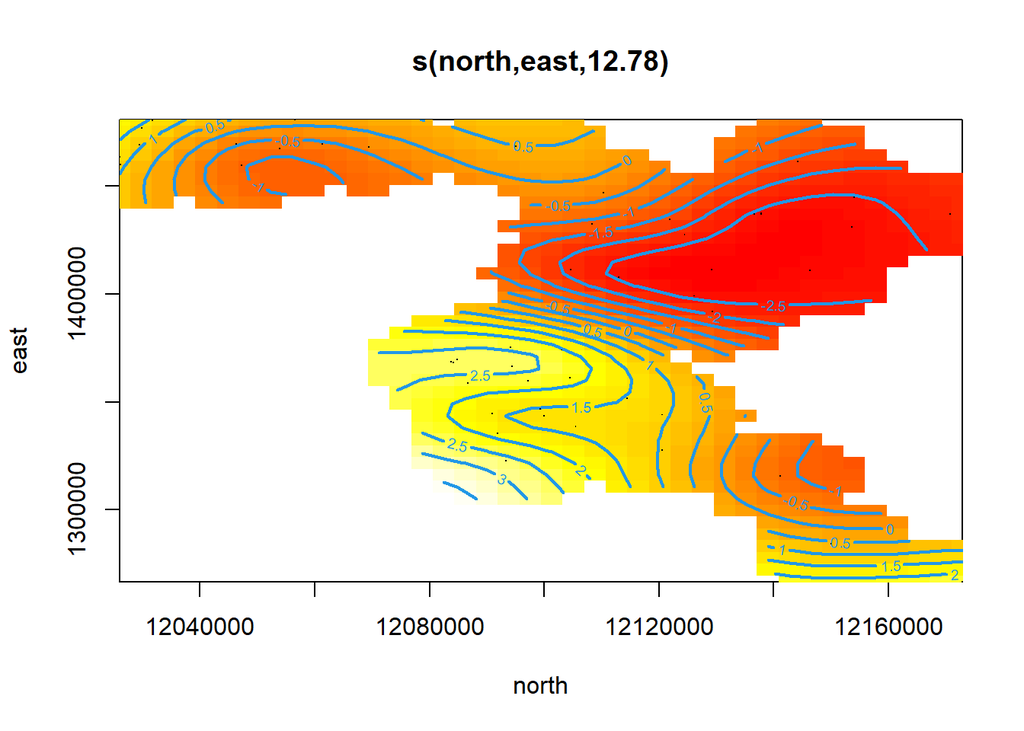

```r
plot(gm2D, select = 1, scheme = 2, lwd = 2)
```

## 1.3 Diagnostics

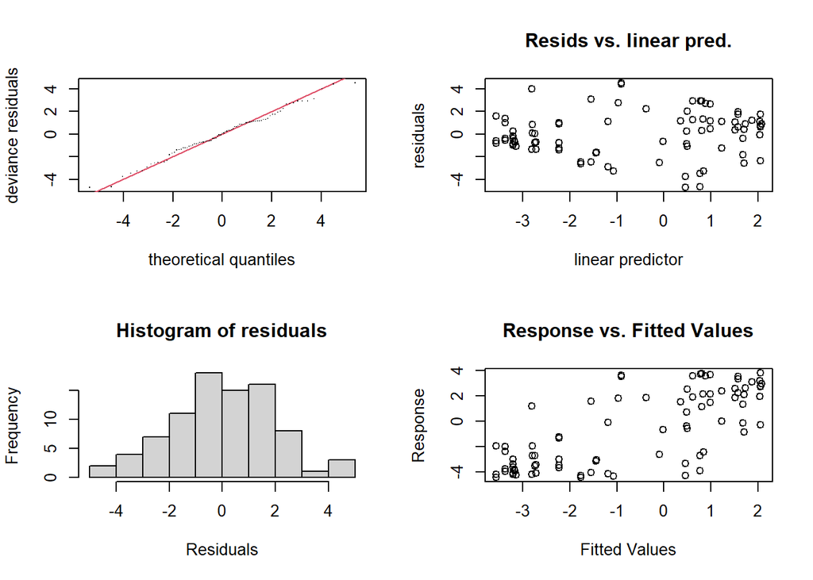

```
##
## Method: GCV   Optimizer: magic
## Smoothing parameter selection converged after 4 iterations.
## The RMS GCV score gradient at convergence was 0.000109521 .
## The Hessian was positive definite.
## Model rank =  20 / 20
##
## Basis dimension (k) checking results. Low p-value (k-index<1) may
## indicate that k is too low, especially if edf is close to k'.
##
##                 k'  edf k-index p-value
## s(north,east) 19.0 12.8    1.02    0.52
```

```r
par(mfrow = c(2,2))
gam.check(gm2D)
```

# 2 Euclidean Distance from APP

To get at question 2, we need a new variable that measures distance from APP. Let’s say the center of APP is at the coordinates 1440000 east, 12160000 north. Make a new column where you calculate the euclidean distance between each individual and the center of APP. Now make a GAM where % ancestry is a smooth function of distance from APP. Do you think this model supports the idea that the relative contribution of coyotes vs. wolves is primarily affected by this park? How does the % deviance explained compare between this model and the model where you fit a 2D smoother to the data? How does estimated degrees of freedom and AICc compare between the two models? How do you interpret these results?

**Answer:** Yes this model supports the hypothesis that the park affects the relative contribution of coyotes vs wolves. The fit is both significant and the plotted effect show a clear increase in coyote percent ancestry as the distance from the park increases. It does not answer weather the distance from the park is the primary affect, as we have not tested any other predictors up until this point. The model with distance from the parks center explains 43.4% of the deviance, while the model with the 2D smoother explains 54.8% of the deviance. The model with a one dimensional distance smoother has about half the degrees of freedom than the model with a two dimensional smoother. The 1D smoother model has a slightly higher AIC score, but is overall not that different $\Delta AIC = 2.5$. The two models are testing a very similar hypothesis. That is, how percent ancestry is spatialy distributed. While the 1D distance model is technically worse, the results are easily interpreted as a simple line plot (shown in the second tab), and it addresses a more specific question, that is… how does the distance from the park effect percent coyote ancestry. As the distance increases, so does percent coyote ancestry. While hunting and trapping is allowed outside of the APP area, it is also more urbanized and it’s believed that coyotes are better adapted survival in urban environments than wolves are.

## 2.1 Model Summary and AIC

```r
#euclidean distance from two points
distance <- function(a, b) sqrt(sum((a - b)^2))

# finding the euclidean distance between the east west coordinates
center <- c(1440000,  12160000)
spots <- cbind(dogs$east, dogs$north)
for (i in 1:nrow(dogs)) dogs$dist[i] <- distance(spots[i,], center)
gm1D <- gam(ancestry ~ s(dist), data= dogs, family = gaussian)

summary(gm1D)
```

```
##
## Family: gaussian
## Link function: identity
##
## Formula:
## ancestry ~ s(dist)
##
## Parametric coefficients:
##             Estimate Std. Error t value Pr(>|t|)
## (Intercept)  -0.5962     0.2483  -2.401   0.0187 *
## ---
## Signif. codes:  0 '***' 0.001 '**' 0.01 '*' 0.05 '.' 0.1 ' ' 1
##
## Approximate significance of smooth terms:
##           edf Ref.df     F  p-value
## s(dist) 6.732  7.814 7.218 9.82e-07 ***
## ---
## Signif. codes:  0 '***' 0.001 '**' 0.01 '*' 0.05 '.' 0.1 ' ' 1
##
## R-sq.(adj) =  0.385   Deviance explained = 43.4%
## GCV = 5.7634  Scale est. = 5.2391    n = 85
```

```r
MuMIn::AICc(gm1D, gm2D)
```

```
##             df     AICc
## gm1D  8.732034 393.6083
## gm2D 14.775865 391.0400
```

## 2.2 Euclidean Distance Effects

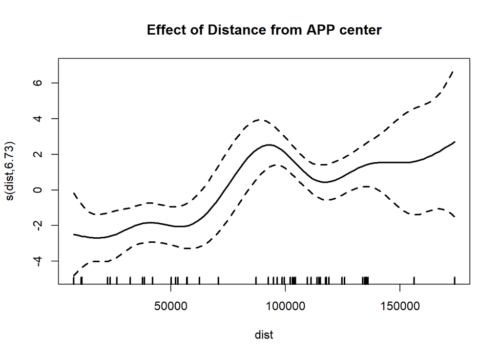

```r
plot(gm1D, select = 1, scheme = 2, lwd = 2)
title("Effect of Distance from APP center")
```

## 2.3 Diagnostocs

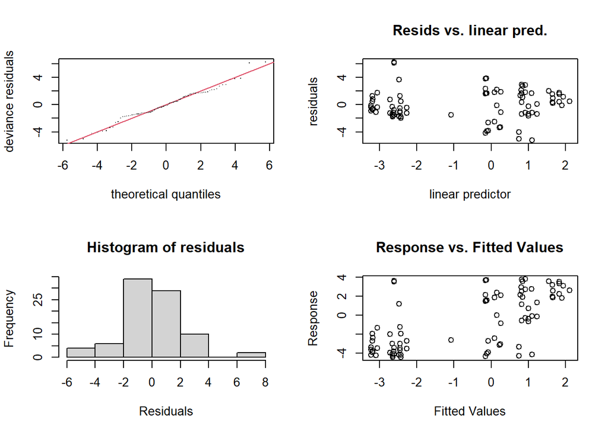

```
##
## Method: GCV   Optimizer: magic
## Smoothing parameter selection converged after 7 iterations.
## The RMS GCV score gradient at convergence was 5.915499e-07 .
## The Hessian was positive definite.
## Model rank =  10 / 10
##
## Basis dimension (k) checking results. Low p-value (k-index<1) may
## indicate that k is too low, especially if edf is close to k'.
##
##           k'  edf k-index p-value
## s(dist) 9.00 6.73    0.85   0.045 *
## ---
## Signif. codes:  0 '***' 0.001 '**' 0.01 '*' 0.05 '.' 0.1 ' ' 1
```

```r
par(mfrow = c(2,2))
gam.check(gm1D)
```

# 3 Other predictors

Question 3 can be addressed by using the environmental predictors in a model. Coyotes are more tolerant of disturbed/human habitats, so predictors like road density (a proxy for human impact) might explain % ancestry. Deer are eaten by both coyotes and wolves, while moose are taken primarily by wolves. Make a GAM where % coyote ancestry is the response, and the predictors are the three road variables, plus deer, moose, and StudyArea. Use a smoother for each predictor (except StudyArea), to see whether it looks like the effect is linear or nonlinear. You may want to transform SecondaryRds, because it has a very skewed distribution. Which of the predictors explain significant variation? Plot the fitted effects, and interpret them in light of what I’ve already discussed about coyotes and wolves.

## 3.1 Model Summary

```r
# transform road2
gm_full = gam(ancestry ~ s(deer) + s(moose) + s(road1) + s(sqrt(road2)) + s(road3) +
                location, data = dogs, family = gaussian)

summary(gm_full)
```

```
##
## Family: gaussian
## Link function: identity
##
## Formula:
## ancestry ~ s(deer) + s(moose) + s(road1) + s(sqrt(road2)) + s(road3) +
##     location
##
## Parametric coefficients:
##             Estimate Std. Error t value Pr(>|t|)
## (Intercept)  -1.8223     0.4330  -4.209 7.14e-05 ***
## locationOut   2.0435     0.6325   3.231  0.00184 **
## ---
## Signif. codes:  0 '***' 0.001 '**' 0.01 '*' 0.05 '.' 0.1 ' ' 1
##
## Approximate significance of smooth terms:
##                  edf Ref.df      F  p-value
## s(deer)        1.000  1.000  0.012  0.91374
## s(moose)       4.086  4.956  3.545  0.00659 **
## s(road1)       1.000  1.000  1.014  0.31716
## s(sqrt(road2)) 1.000  1.000 18.570 5.02e-05 ***
## s(road3)       1.978  2.511  2.627  0.06427 .
## ---
## Signif. codes:  0 '***' 0.001 '**' 0.01 '*' 0.05 '.' 0.1 ' ' 1
##
## R-sq.(adj) =  0.566   Deviance explained = 61.8%
## GCV = 4.2468  Scale est. = 3.694     n = 85
```

## 3.2 Plotting the effect

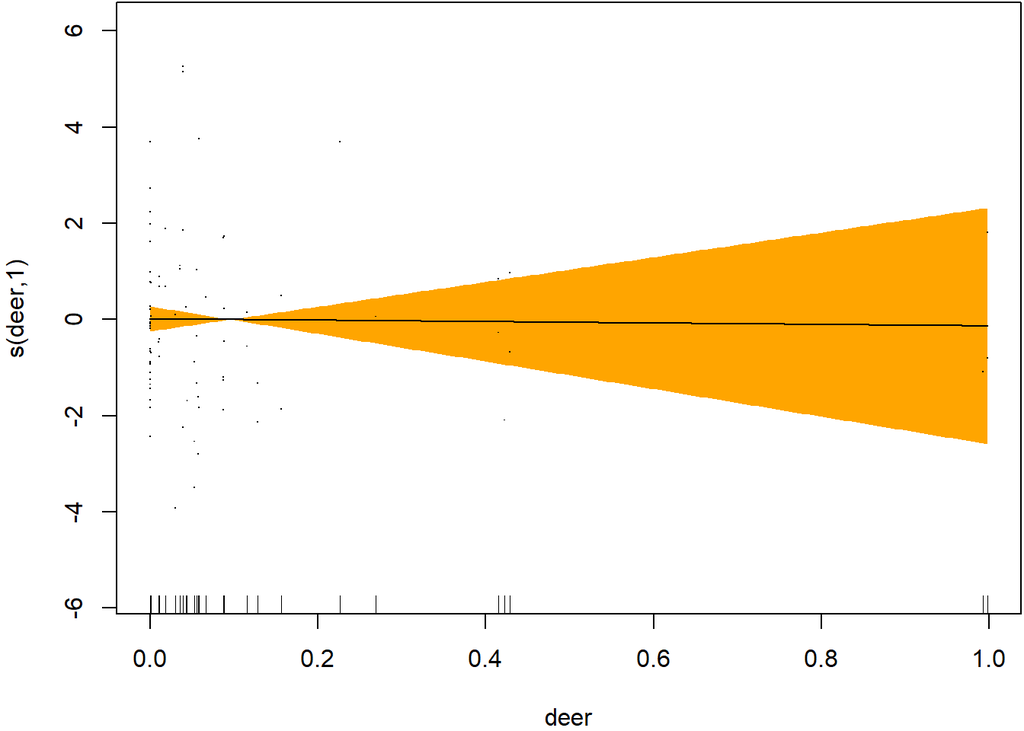

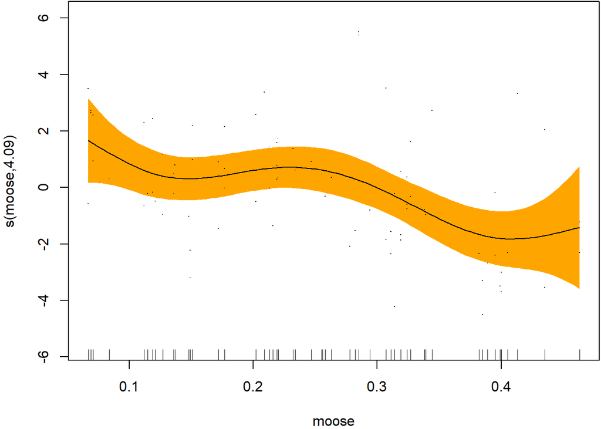

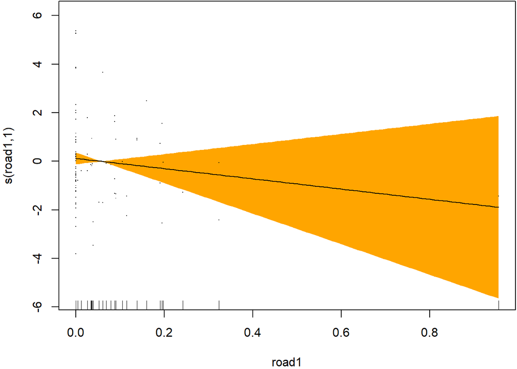

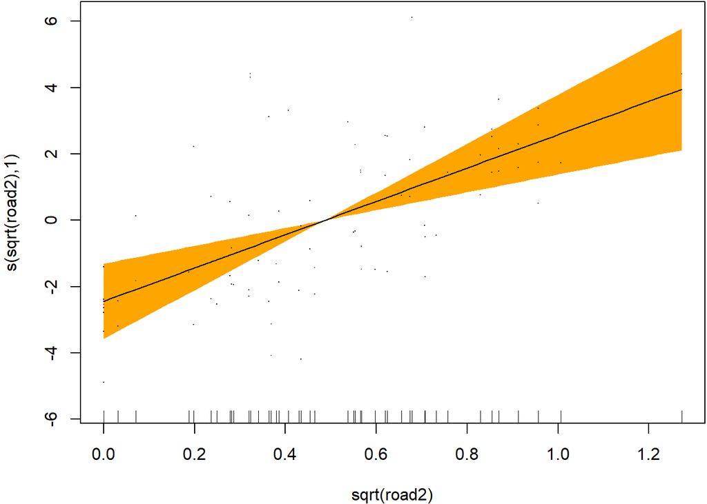

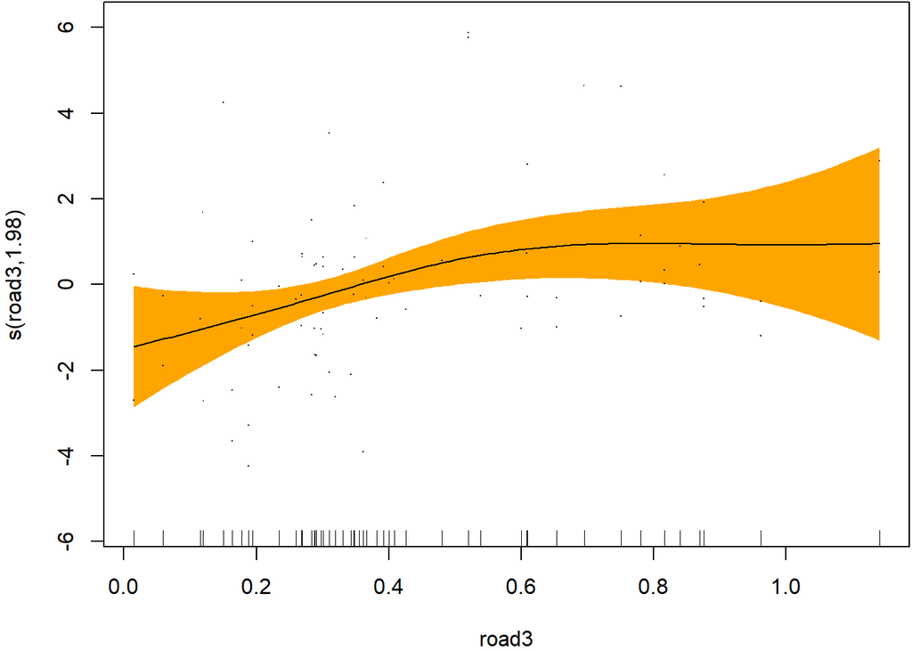

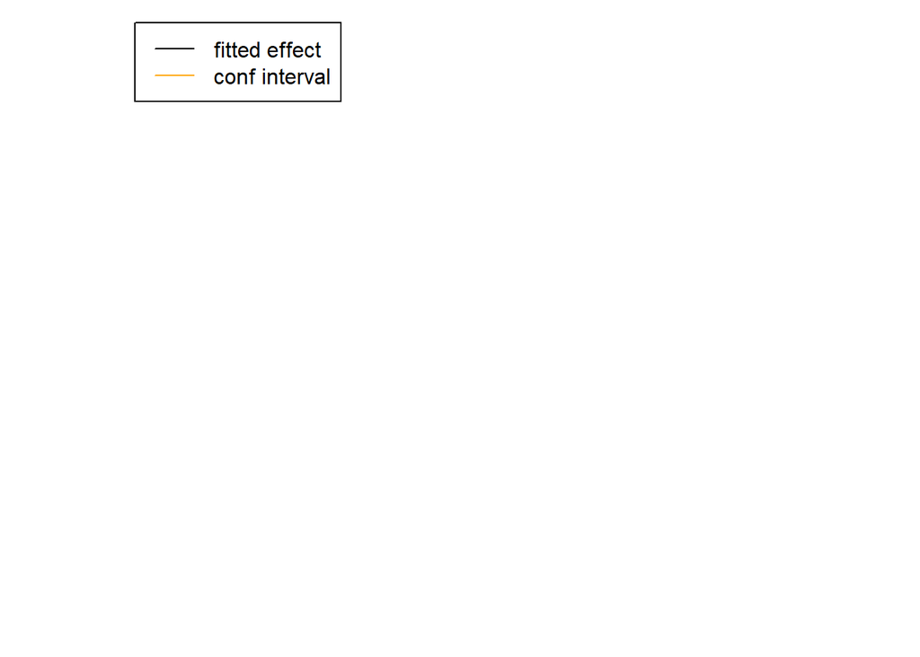

```r
par(mar = c(4, 4, .1, .1))
plot(gm_full, select = 1, residuals = T, shade.col = 'orange', shade = T, col = 'black')
plot(gm_full, select = 2, residuals = T, shade.col = 'orange', shade = T, col = 'black')
plot(gm_full, select = 3, residuals = T, shade.col = 'orange', shade = T, col = 'black')
plot(gm_full, select = 4, residuals = T, shade.col = 'orange', shade = T, col = 'black')
plot(gm_full, select = 5, residuals = T, shade.col = 'orange', shade = T, col = 'black')
# I'd like to plot as colored points
plot(NULL ,xaxt='n',yaxt='n',bty='n',ylab='',xlab='', xlim=0:1, ylim=0:1)
legend(x = 0, y = 1,
       legend = c("fitted effect", "conf interval"),
       lty = c(1, 1), col = c("black", "orange"))

#plot(dogs$east, dogs$north, col = (gm_full$fitted.values - min(gm_full$fitted.values)))
```

# 4 Interaction Tertiary Roads

The authors hypothesized that the effect of tertiary roads (smaller country roads) might differ if the animals are inside or outside of APP, because those roads are the most important for hunting/trapping access, but the animals are protected inside of APP. Amend the model you just made to include an interaction between the smoother for tertiary roads and StudyArea. Does it look like the interaction is important? How does this model compare based on AICc? What do you think the interaction means? Consider that wolves and coyotes may be differentially susceptible to human effects.

## 4.1 Model Summary and AICc

```r
# hist(sqrt(dogs$road2))
# How APP differs the overall relationship fit by the first smoother.
gm_both <- gam(ancestry ~ s(deer) + s(moose) + s(road1) + s(sqrt(road2)) + location + s(road3, by = location),
              data   = dogs,
              family = gaussian)

ind     <- as.numeric(dogs$location == "APP")
gm_in <- gam(ancestry ~ s(deer) + s(moose) + s(road1) + s(sqrt(road2)) + s(road3) + location + s(road3, by = ind),
              data = dogs,
              family = gaussian)

summary(gm_in)
```

```
##
## Family: gaussian
## Link function: identity
##
## Formula:
## ancestry ~ s(deer) + s(moose) + s(road1) + s(sqrt(road2)) + s(road3) +
##     location + s(road3, by = ind)
##
## Parametric coefficients:
##             Estimate Std. Error t value Pr(>|t|)
## (Intercept)  -0.9676     6.2871  -0.154    0.878
## locationOut   1.2359     6.2965   0.196    0.845
##
## Approximate significance of smooth terms:
##                  edf Ref.df      F  p-value
## s(deer)        1.000  1.000  1.608  0.20902
## s(moose)       4.431  5.414  3.485  0.00667 **
## s(road1)       1.000  1.000  1.701  0.19641
## s(sqrt(road2)) 1.000  1.000 24.320 5.64e-06 ***
## s(road3)       1.000  1.000  8.639  0.00446 **
## s(road3):ind   5.439  6.130  2.907  0.01680 *
## ---
## Signif. codes:  0 '***' 0.001 '**' 0.01 '*' 0.05 '.' 0.1 ' ' 1
##
## Rank: 56/57
## R-sq.(adj) =  0.628   Deviance explained = 69.1%
## GCV = 3.8546  Scale est. = 3.1652    n = 85
```

```r
summary(gm_both)
```

```
##
## Family: gaussian
## Link function: identity
##
## Formula:
## ancestry ~ s(deer) + s(moose) + s(road1) + s(sqrt(road2)) + location +
##     s(road3, by = location)
##
## Parametric coefficients:
##             Estimate Std. Error t value Pr(>|t|)
## (Intercept)   -2.410      1.702  -1.416    0.161
## locationOut    2.678      1.734   1.544    0.127
##
## Approximate significance of smooth terms:
##                        edf Ref.df      F  p-value
## s(deer)              1.000  1.000  1.608  0.20902
## s(moose)             4.431  5.414  3.485  0.00667 **
## s(road1)             1.000  1.000  1.701  0.19641
## s(sqrt(road2))       1.000  1.000 24.320 5.64e-06 ***
## s(road3):locationAPP 4.772  5.464  2.006  0.05909 .
## s(road3):locationOut 1.000  1.000  8.639  0.00446 **
## ---
## Signif. codes:  0 '***' 0.001 '**' 0.01 '*' 0.05 '.' 0.1 ' ' 1
##
## R-sq.(adj) =  0.628   Deviance explained = 69.1%
## GCV = 3.8546  Scale est. = 3.1652    n = 85
```

```r
# showing they basically the same model
MuMIn::AICc(gm_in, gm_both, gm_full)
```

```
##               df     AICc
## gm_in   16.20325 363.0367
## gm_both 16.20325 363.0367
## gm_full 12.06419 368.9469
```

## 4.2 Plotted Model Effects

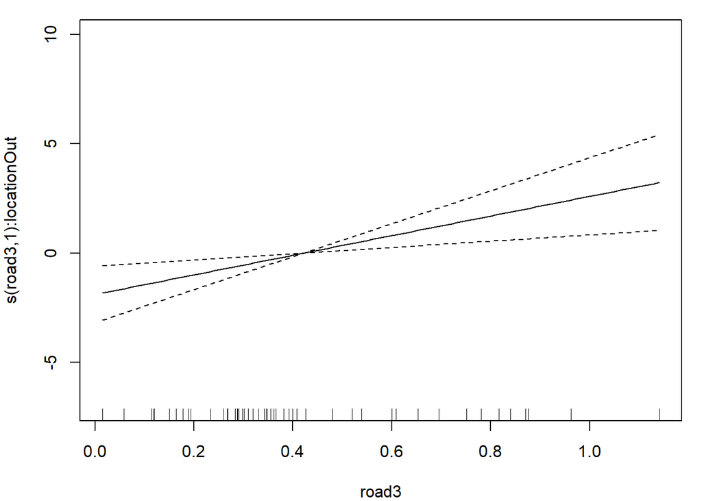

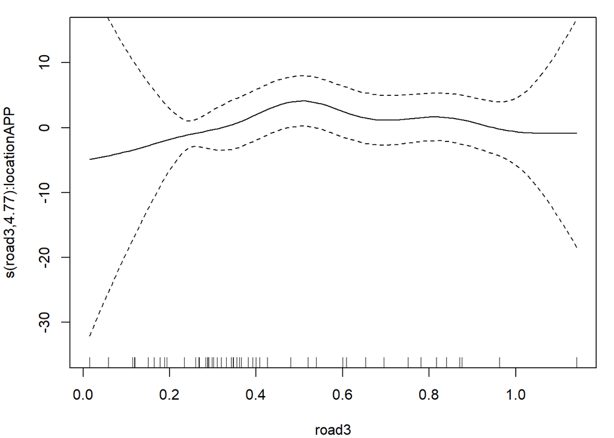

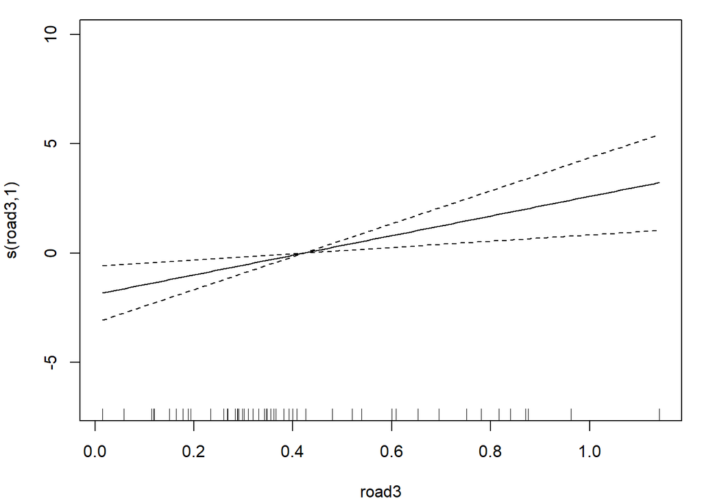

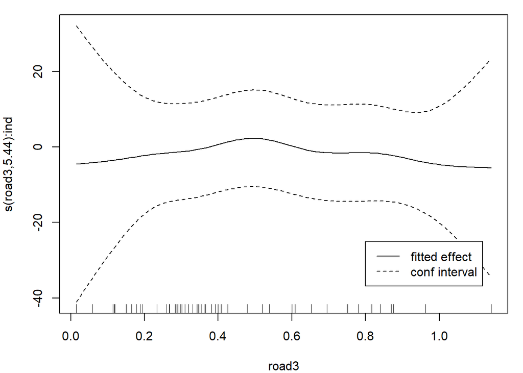

```r
par(mar = c(4, 4, 1, 1))
plot(gm_both,
     select = 6,
     residuals = F,
     shade = F,
     col = 'black',
     ylim = c(-7, 10))
plot(gm_both,
     select = 5,
     residuals = F,
     shade = F,
     col = 'black',
     ylim = c(-35, 15))
plot(gm_in,
     select = 5,
     residuals = F,
     shade = F,
     col = 'black',
     ylim = c(-7, 10))
plot(gm_in,
     select = 6,
     residuals = F,
     shade = F,
     col = 'black')
     #ylim = c(-7, 10))
legend(x = 0.8, y = -25,
       legend = c("fitted effect", "conf interval"),
       lty = c(1, 2), col = c("black", "black"))
```

# 5 Spatially autocorrelion: Semivariogram

For the models you have used for Question 3, we have not explicitly accounted for spatial structure. That may lead to spatial autocorrelation of the data, based on the spatial structure we looked at for Q1. Based on the code from the lecture notes, plot a bubble plot and semivariogram of the residuals of the model that includes the TertiaryRds*StudyArea interaction. Does it look the residuals are spatially autocorrelated? Now make a new model that adds in the 2D spatial smoother that you used previously. Compare the evidence for spatial autocorrelation between this model and the model without the smoother. Does accounting for autocorrelation with the 2D smoother change whether you think the other predictors are important

**Answer:** In the first tab I plotted the semivariogram and bubble plots of depicting the affect of autocorrelation. Clumps of similarly collered bubbles indicate spatial autocorelation. The top row is the model without a 2D smoother, the second row from a model with a 2D spatial smoother, and the botom row is of plots without and predictors.

```r
check <- function(mod, df, main = ""){
  dat <- data.frame(lon = df$east, lat = df$north, resids = resid(mod))
  coordinates(dat) <- c('lon', 'lat')
  v1 <- variog(coords = df[ , c('east','north')], data = residuals(mod, type = 'pearson'), messages = FALSE)

  print(bubble(dat,zcol='resids', main = paste("Residuals of ", main, sep = "")))
  plot(v1)
  title(paste("semivariogram of ", main, sep = ""))
  }
```

## 5.1 Plotted effects

```r
gm_noD <- gam(ancestry ~ s(deer) + s(moose) + s(road1) + s(sqrt(road2)) +
                location + s(road3, by = location),
              data   = dogs,
              family = gaussian)

gm_2D <- gam(ancestry ~ s(deer) + s(moose) + s(road1) + s(sqrt(road2)) +
               location + s(road3, by = location) +  s(north, east, k = 20),
              data   = dogs,
              family = gaussian)

gm.nopred = gam(ancestry ~ 1, data = dogs, family = gaussian)

par(mar = c(4, 4, 2, 2))
check(gm_noD, dogs,  main = "GAM with no spatial smoother")
```

```
## variog: co-locatted data found, adding one bin at the origin
```

```r
check(gm_2D, dogs, main = "GAM with a 2d spatial smoother")
```

```
## variog: co-locatted data found, adding one bin at the origin
```

```r
check(gm.nopred, dogs, main = "GAM with no predictors")
```

```
## variog: co-locatted data found, adding one bin at the origin
```

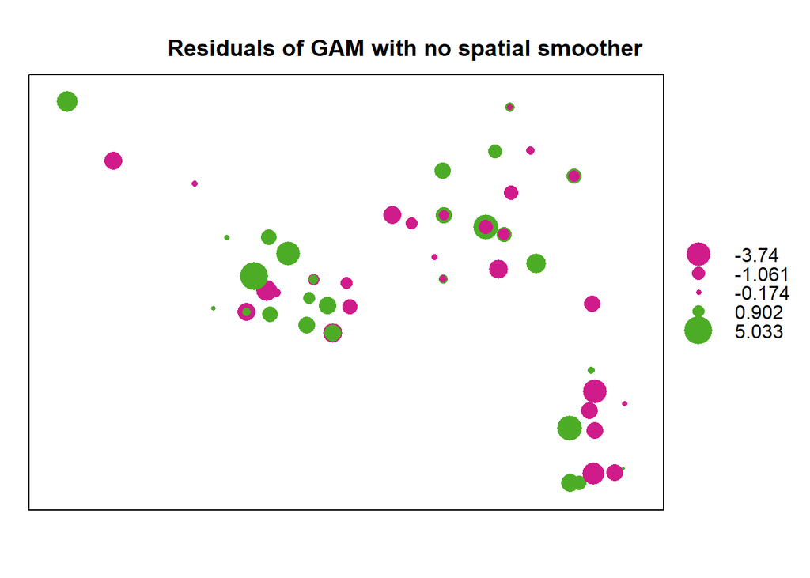

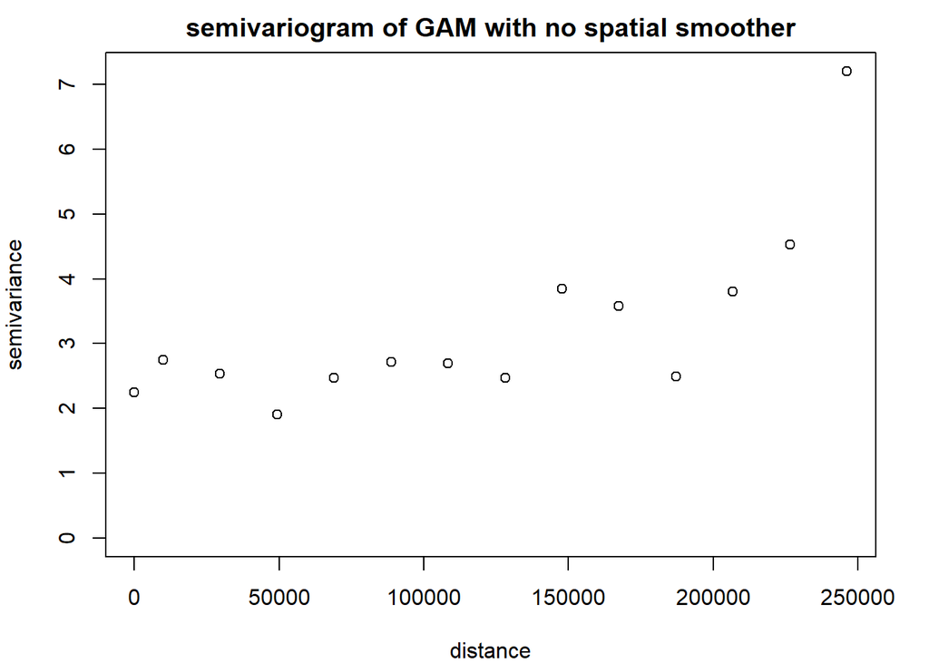

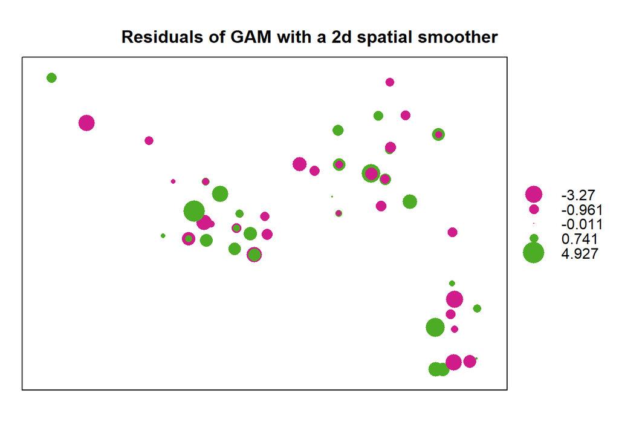

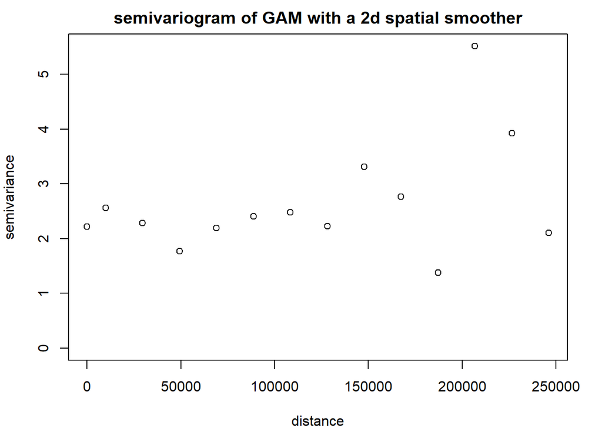

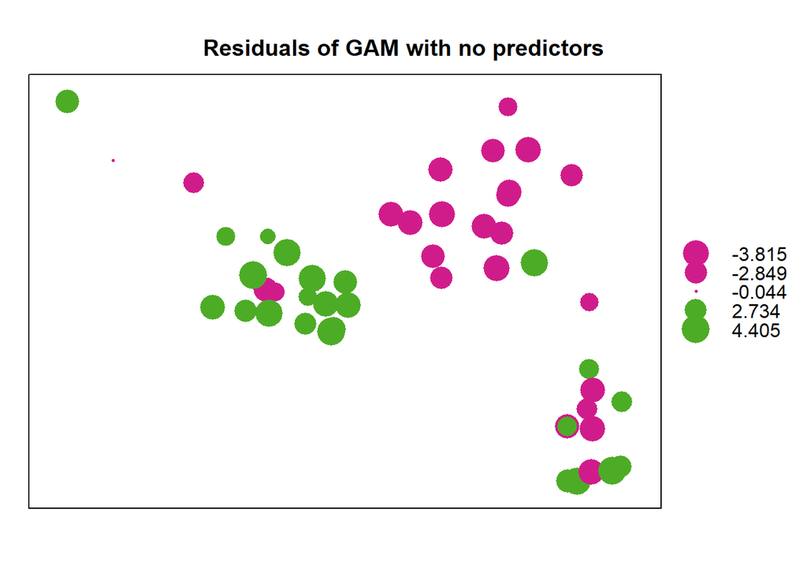

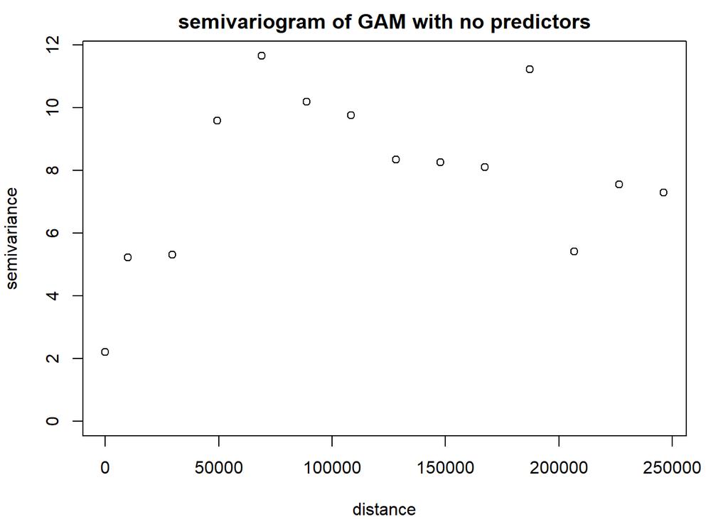

## 5.2 2D Model Summary

```r
summary(gm_2D)
```

```
##
## Family: gaussian
## Link function: identity
##
## Formula:
## ancestry ~ s(deer) + s(moose) + s(road1) + s(sqrt(road2)) + location +
##     s(road3, by = location) + s(north, east, k = 20)
##
## Parametric coefficients:
##             Estimate Std. Error t value Pr(>|t|)
## (Intercept)   -4.232      1.781  -2.377   0.0204 *
## locationOut    5.011      2.182   2.297   0.0248 *
## ---
## Signif. codes:  0 '***' 0.001 '**' 0.01 '*' 0.05 '.' 0.1 ' ' 1
##
## Approximate significance of smooth terms:
##                        edf Ref.df     F p-value
## s(deer)              1.000  1.000 0.005 0.94478
## s(moose)             4.405  5.354 3.842 0.00379 **
## s(road1)             1.000  1.000 0.331 0.56681
## s(sqrt(road2))       3.674  4.547 4.620 0.00129 **
## s(road3):locationAPP 3.791  4.520 2.149 0.04477 *
## s(road3):locationOut 1.000  1.000 5.577 0.02116 *
## s(north,east)        2.132  2.248 2.324 0.10177
## ---
## Signif. codes:  0 '***' 0.001 '**' 0.01 '*' 0.05 '.' 0.1 ' ' 1
##
## R-sq.(adj) =  0.647   Deviance explained = 72.3%
## GCV = 3.8674  Scale est. = 3.0029    n = 85
```